# Hopf Bifurcations in 2D (Assignment Sheet 7)

Introduction To Chaos Applied To Systems, Processes And Products (ETSIDI, UPM)

Alfonso Allen-Perkins, Juan Carlos Bueno and Eduardo Faleiro

2026-02-03

# Introduction

In nonlinear dynamics, a **Hopf bifurcation** occurs when a fixed point of a system changes stability and a **limit cycle** (periodic orbit) appears or disappears. Depending on the system, the bifurcation can be:

- **Supercritical**: A supercritical Hopf bifurcation occurs when a stable spiral changes into an unstable spiral surrounded by a small, nearly elliptical limit cycle.
- **Subcritical**: A fixed point switches from unstable to stable, and at that same critical point, an unstable limit cycle emerges.

We’ll illustrate both with examples.

# Supercritical Hopf bifurcation

A simple example of a supercritical Hopf bifurcation can be written in polar coordinates as:
$$\begin{aligned}
\dot{r} &= \mu r - r^3 \\
\dot{\theta} & = \omega
\end{aligned}$$
The system depends on two parameters:

- $\mu$ controls the stability of the fixed point at the origin.
- $\omega$ sets the frequency of small-amplitude oscillations.

When $\mu < 0$, the origin ($r = 0$) is a **stable spiral**, with the direction of rotation determined by the sign of $\omega$.

As $\mu$ increases and crosses zero, a **Hopf bifurcation** occurs. For $\mu > 0$, the origin becomes an **unstable spiral**, and a **stable circular limit cycle** emerges at radius $r = \sqrt{\mu}$.

## Simulation with two trajectories and vector field

To simulate solutions and visualize the vector field, we rewrite the system in Cartesian coordinates. Starting from the polar-to-Cartesian transformation:

$$\begin{aligned}
x=r\cos(\theta) \rightarrow \dot{x} &= \dot{r}\cos(\theta)-r
\dot{\theta} \sin(\theta) \\
y=r\sin(\theta) \rightarrow \dot{y} &= \dot{r}\sin(\theta)+r
\dot{\theta} \cos(\theta)
\end{aligned}$$
Substituting the expressions for $\dot{r} = \mu r - r^3$ and $\dot{\theta} = \omega$, we obtain:

$$\begin{aligned}
\dot{x} &= (\mu r - r^3)\frac{x}{r}-r \omega \frac{y}{r} \\
\dot{y} &= (\mu r - r^3)\frac{y}{r}+r \omega \frac{x}{r}
\end{aligned}$$
where $r=\sqrt(x^2+y^2)$. This formulation enables us to simulate the dynamics and plot the vector field directly in Cartesian coordinates.

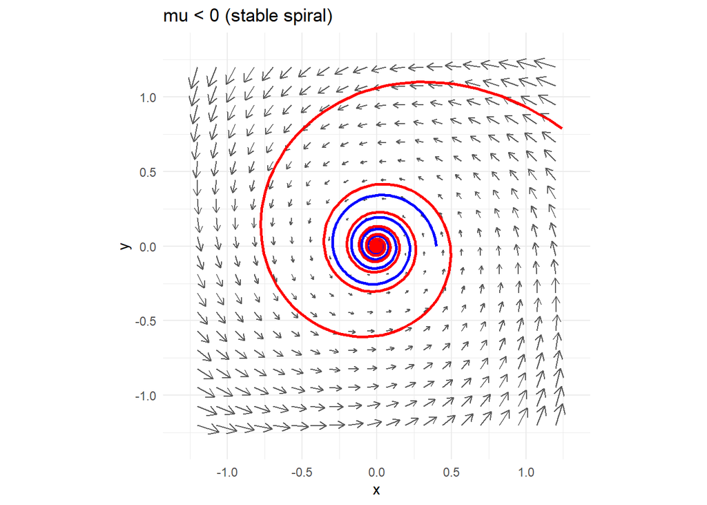

```r
# Load the required libraries
library(deSolve)
library(ggplot2)
library(ggquiver)

# Define the polar system with the supercritical Hopf bifurcation
supercritical <- function(t, state, parameters) {
  r <- state[1]
  theta <- state[2]

  mu <- parameters["mu"]
  omega <- parameters["omega"]

  dr <- mu * r - r^3
  dtheta <- omega
  list(c(dr, dtheta))
}

# Set common initial conditions to study two trajectories (one for mu < 0 and
# the otherone for mu> 0)
state1 <- c(r = 0.4, theta = 0)
state2 <- c(r = 2, theta = 0)

# Set parameters and time for numerical integration, before the bifurcation (mu<0)
parameters_neg_mu <- c(mu = -0.5, omega = 2 * pi)
times <- seq(0, 50, by = 0.01)

# Set parameters and time for numerical integration, before the bifurcation (mu>0)
parameters_pos_mu <- c(mu = 0.5, omega = 2 * pi)
times <- seq(0, 50, by = 0.01)

# Function to simulate and convert polar to cartesian
simulate_hopf <- function(state, parameters, times) {

  # Trajectory for state
  result <- ode(y = state, times = times, func = supercritical, parms = parameters)
  result_df <- as.data.frame(result)
  result_df$x <- result_df$r * cos(result_df$theta)
  result_df$y <- result_df$r * sin(result_df$theta)

  return(result_df)

}

# Vector field in Cartesian coordinates
make_vecfield <- function(mu, omega = 2 * pi) {
  grid <- expand.grid(x = seq(-1.2, 1.2, length.out = 20),
                      y = seq(-1.2, 1.2, length.out = 20))
  grid$r <- sqrt(grid$x * grid$x + grid$y * grid$y)
  grid$costheta <- grid$x /grid$r
  grid$sintheta <- grid$y /grid$r
  grid$dr <- mu * grid$r - grid$r^3
  grid$dx <- grid$dr * grid$costheta - grid$r * omega * grid$sintheta
  grid$dy <- grid$dr * grid$sintheta + grid$r * omega * grid$costheta
  grid
}

# Simulations (mu < 0)
sol_1_neg_mu <- simulate_hopf(state1, parameters_neg_mu, times)
sol_2_neg_mu <- simulate_hopf(state2, parameters_neg_mu, times)

# Simulations (mu > 0)
sol_1_pos_mu <- simulate_hopf(state1, parameters_pos_mu, times)
sol_2_pos_mu <- simulate_hopf(state2, parameters_pos_mu, times)

# Vector fields for mu < 0 and mu > 0 respectively
vec_neg <- make_vecfield(mu = -0.5)
vec_pos <- make_vecfield(mu = 0.5)


# Plot for mu < 0
ggplot() +
  geom_quiver(data = vec_neg, aes(x, y, u = dx, v = dy), vecsize = 1.2, color = "gray35") +
  geom_path(data = sol_1_neg_mu, aes(x = x, y = y), color = "blue", linewidth = 1) +
  geom_path(data = sol_2_neg_mu, aes(x = x, y = y), color = "red", linewidth = 1) +
  ggtitle("mu < 0 (stable spiral)") +
  xlim(-1.3,1.3)+
  ylim(-1.3,1.3)+
  coord_equal() +
  theme_minimal()
```

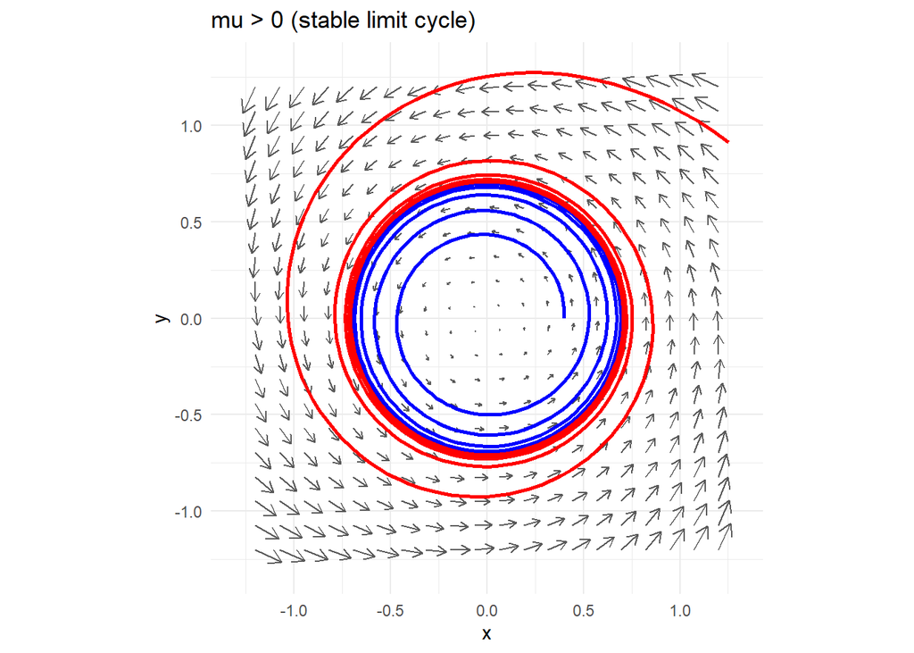

```r
# Plot for mu > 0
ggplot() +
  geom_quiver(data = vec_pos, aes(x, y, u = dx, v = dy), vecsize = 1.2, color = "gray35") +
  geom_path(data = sol_1_pos_mu, aes(x = x, y = y), color = "blue", linewidth = 1) +
  geom_path(data = sol_2_pos_mu, aes(x = x, y = y), color = "red", linewidth = 1) +
  xlim(-1.3,1.3)+
  ylim(-1.3,1.3)+
  ggtitle("mu > 0 (stable limit cycle)") +
  coord_equal() +
  theme_minimal()
```

# Subcritical Hopf bifurcation

A simple example of a subcritical Hopf bifurcation can be written in polar coordinates as:
$$\begin{aligned}
\dot{r} &= \mu r + r^3 - r^5 \\
\dot{\theta} & = \omega
\end{aligned}$$
The system depends on two parameters:

- $\mu$ controls the stability of the fixed point at the origin.
- $\omega$ sets the frequency of small-amplitude oscillations.

When $-0.25 < \mu < 0$, the system exhibits **bistability**, with two attractors: a **stable limit cycle** and a **stable fixed point** at $r = 0$. Separating them is an **unstable limit cycle** (see an example for in Appendix 1 for $\mu = -0.1$). Trajectories that start between the unstable limit cycle and one of the attractors spiral stably toward the corresponding attractor. The direction of rotation is determined by the sign of $\omega$.

As $\mu$ increases and crosses zero, a **subcritical Hopf bifurcation** occurs. For $\mu > 0$, the unstable limit cycle collapses into the origin, destabilizing it. The only surviving attractor is the **stable limit cycle**, which now dominates the dynamics.

## Simulation with several trajectories and vector field

To simulate solutions and visualize the vector field, we rewrite the system in Cartesian coordinates. Starting from the polar-to-Cartesian transformation:

$$\begin{aligned}
\dot{x} &= (\mu r + r^3- r^5)\frac{x}{r}-r \omega \frac{y}{r} \\
\dot{y} &= (\mu r + r^3- r^5)\frac{y}{r}+r \omega \frac{x}{r}
\end{aligned}$$
where $r=\sqrt(x^2+y^2)$. This formulation enables us to simulate the dynamics and plot the vector field directly in Cartesian coordinates.

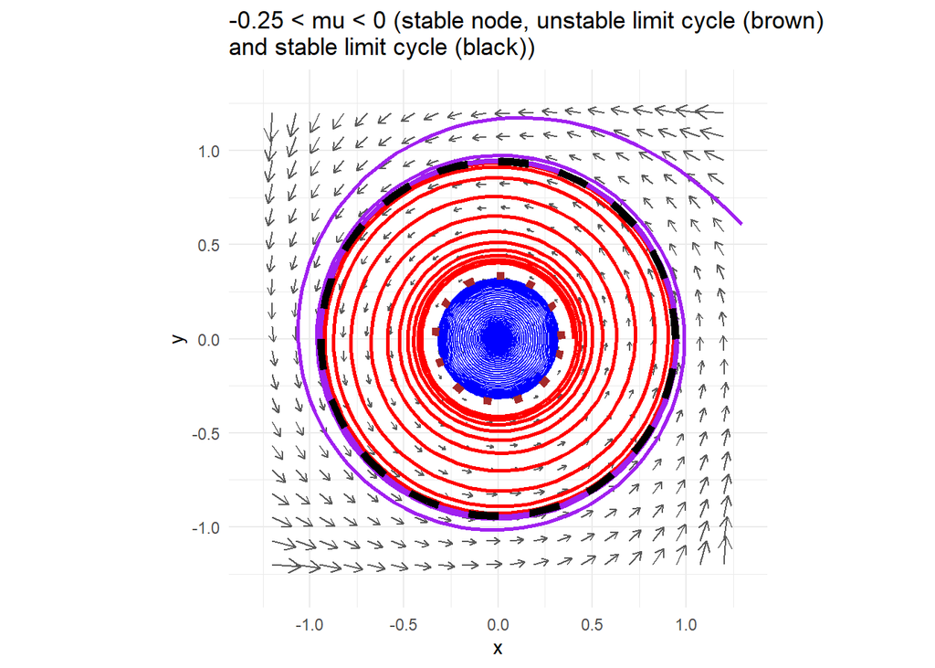

```r
# Load the required libraries
library(deSolve)
library(ggplot2)
library(ggquiver)

# Define the polar system with the subcritical Hopf bifurcation
subcritical <- function(t, state, parameters) {
  r <- state[1]
  theta <- state[2]

  mu <- parameters["mu"]
  omega <- parameters["omega"]

  dr <- mu * r + r^3 - r^5
  dtheta <- omega

  list(c(dr, dtheta))
}


# Set common initial conditions to study two trajectories (one for mu < 0 and
# the otherone for mu> 0)
state1 <- c(r = 0.32, theta = 0)
state2 <- c(r = .4, theta = 0)
state3 <- c(r = 2, theta = 0)

# Set parameters and time for numerical integration, before the bifurcation (mu<0)
parameters_neg_mu <- c(mu = -0.1, omega = 2 * pi)
times <- seq(0, 100, by = 0.01)

# Set parameters and time for numerical integration, before the bifurcation (mu>0)
parameters_pos_mu <- c(mu = 0.1, omega = 2 * pi)
times <- seq(0, 20, by = 0.01)
times_large <- seq(0, 200, by = 0.01)

# Function to simulate and convert polar to cartesian
simulate_hopf_sub <- function(state, parameters, times) {

  # Trajectory for state
  result <- ode(y = state, times = times, func = subcritical, parms = parameters)
  result_df <- as.data.frame(result)
  result_df$x <- result_df$r * cos(result_df$theta)
  result_df$y <- result_df$r * sin(result_df$theta)

  return(result_df)

}

# Vector field in Cartesian coordinates
make_vecfield_sub <- function(mu, omega = 2 * pi) {
  grid <- expand.grid(x = seq(-1.2, 1.2, length.out = 20),
                      y = seq(-1.2, 1.2, length.out = 20))
  grid$r <- sqrt(grid$x^2 + grid$y^2)
  grid$costheta <- grid$x /grid$r
  grid$sintheta <- grid$y /grid$r
  grid$dr <- mu * grid$r + grid$r^3 - grid$r^5
  grid$dx <- grid$dr * grid$costheta - grid$r * omega * grid$sintheta
  grid$dy <- grid$dr * grid$sintheta + grid$r * omega * grid$costheta
  grid
}

# Simulations (mu < 0)
sol_1_neg_mu_sub <- simulate_hopf_sub(state1, parameters_neg_mu, times_large)
sol_2_neg_mu_sub <- simulate_hopf_sub(state2, parameters_neg_mu, times)
sol_3_neg_mu_sub <- simulate_hopf_sub(state3, parameters_neg_mu, times)

# Simulations (mu > 0)
sol_1_pos_mu_sub <- simulate_hopf_sub(state1, parameters_pos_mu, times)
sol_2_pos_mu_sub <- simulate_hopf_sub(state2, parameters_pos_mu, times)
sol_3_pos_mu_sub <- simulate_hopf_sub(state3, parameters_pos_mu, times)

# Vector fields for mu < 0 and mu > 0 respectively
vec_neg_sub <- make_vecfield_sub(mu = -.1)
vec_pos_sub <- make_vecfield_sub(mu = .1)

# limit cycles ( mu = -0.1, appendix 1)
seq_theta <- c(seq(0, 2 * pi, by = 0.1), 0)
limit_cycle_stable_neg <- data.frame(x = 0.942*cos(seq_theta),
                                 y = 0.942*sin(seq_theta)
)

limit_cycle_unstable_neg <- data.frame(x = 0.336*cos(seq_theta),
                                   y = 0.336*sin(seq_theta)
)

# limit cycles ( mu = 0.1, not included)
limit_cycle_stable_pos <- data.frame(x = 1.0448*cos(seq_theta),
                                     y = 1.0448*sin(seq_theta)
)



# Plot for mu < 0
ggplot() +
  geom_quiver(data = vec_neg_sub, aes(x, y, u = dx, v = dy),
              vecsize = 1.2, color = "gray35") +
  geom_path(data = sol_1_neg_mu_sub, aes(x = x, y = y),
            color = "blue", linewidth = .5) +
  geom_path(data = sol_2_neg_mu_sub, aes(x = x, y = y),
            color = "red", linewidth = 1) +
  geom_path(data = sol_3_neg_mu_sub, aes(x = x, y = y),
            color = "purple", linewidth = 1) +
  geom_path(data = limit_cycle_stable_neg, aes(x = x, y = y),
            color = "black", linetype = "dashed", linewidth = 2) +
  geom_path(data = limit_cycle_unstable_neg, aes(x = x, y = y),
            color = "brown", linetype = "dotted", linewidth = 2) +
  ggtitle("-0.25 < mu < 0 (stable node, unstable limit cycle (brown)\nand stable limit cycle (black))") +
  xlim(-1.3,1.3)+
  ylim(-1.3,1.3)+
  coord_equal() +
  theme_minimal()
```

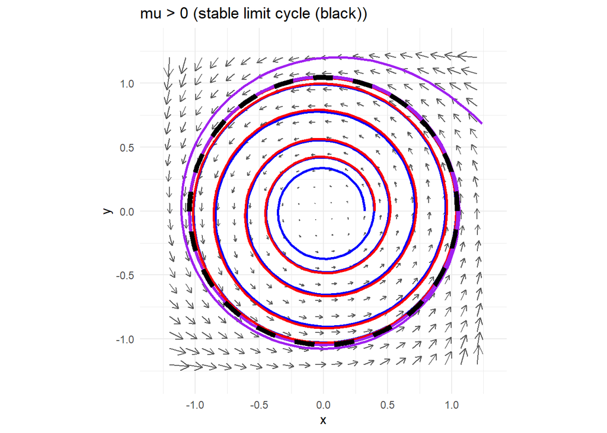

```r
# Plot for mu > 0
ggplot() +
  geom_quiver(data = vec_pos_sub, aes(x, y, u = dx, v = dy),
              vecsize = 1.2, color = "gray35") +
  geom_path(data = sol_1_pos_mu_sub, aes(x = x, y = y),
            color = "blue", linewidth = 1) +
  geom_path(data = sol_2_pos_mu_sub, aes(x = x, y = y),
            color = "red", linewidth = 1) +
  geom_path(data = sol_3_pos_mu_sub, aes(x = x, y = y),
            color = "purple", linewidth = 1) +
  geom_path(data = limit_cycle_stable_pos, aes(x = x, y = y),
            color = "black", linetype = "dashed", linewidth = 2) +
  xlim(-1.3,1.3)+
  ylim(-1.3,1.3)+
  ggtitle("mu > 0 (stable limit cycle (black))") +
  coord_equal() +
  theme_minimal()
```

# Appendix 1: Finding the limit cycles for the subcritical Hopf bifurcation when $\mu = -0.1$

Consider the radial equation $\dot{r} = \mu r + r^3 - r^5$, with $\mu = -0.1$. We look for limit cycles, which correspond to positive roots of $\mu r + r^3 - r^5 = 0 \rightarrow \mu + r^2 - r^4 = 0$. Aside from the trivial solution $r=0$, any positive root of $\mu + r^2 - r^4 = 0 \rightarrow r^4 - r^2 - \mu = 0$ gives the radius of a limit cycle. Below, we solve this numerically and determine which cycles are stable vs. unstable by checking the sign of $f'(r) = \frac{d}{dr} \left( \mu r + r^3 - r^5 \right) = \mu + 3r^2 - 5r^4$. If $f'(r_0) < 0$, the cycle at $r = r_0$ is stable; if $f'(r_0) > 0$, it is unstable.

```r
# Parameter
mu <- -0.1

# We want to solve mu*r + r^3 - r^5 = 0
# polyroot() expects polynomial coefficients in ascending order:
#    p(x) = a0 + a1*x + a2*x^2 + a3*x^3 + a4*x^4 + a5*x^5
# Here, that corresponds to 0 + (mu)*x + 0*x^2 + 1*x^3 + 0*x^4 + (-1)*x^5
roots_r <- polyroot(c(0, mu, 0, 1, 0, -1))

# Define the derivative f'(r) = mu + 3*r^2 - 5*r^4
fprime <- function(r) {
  mu + 3*r^2 - 5*r^4
}

# Evaluate f'(r) for each root
fprime_roots_r <- fprime(roots_r)

# Determine stability: if f'(r) < 0 => "Stable", else "Unstable"
# Use ifelse() to handle multiple roots at once.
stability_roots_r <- ifelse(Re(fprime_roots_r) < 0, "Stable", "Unstable")

# Print out the stability classification
data.frame(root = roots_r,
           real_part = Re(roots_r),
           imaginary_part = round(Im(roots_r), 10),
           stability = stability_roots_r)
```

```
##                       root  real_part imaginary_part stability
## 1  0.0000000+0.000000e+00i  0.0000000              0    Stable
## 2  0.3357107+0.000000e+00i  0.3357107              0  Unstable
## 3 -0.3357107-4.038968e-28i -0.3357107              0  Unstable
## 4 -0.9419651-5.169879e-26i -0.9419651              0    Stable
## 5  0.9419651+5.210269e-26i  0.9419651              0    Stable
```

## Interpretation

We obtain two positive solutions $r_1 \approx 0.336$ and $r_2 \approx 0.942$.

Checking $f'(r)$ shows that:

- $r_1$ is **unstable** (because $f'(r_1)>0$)
- $r_2$ is **stable** (because $f'(r_2)<0$)

Hence, at $\mu =-0.1$, there is one unstable limit cycle at the smaller radius and one stable limit cycle at the larger radius. The trivial solution $r=0$ also exists, but its stability typically depends on $\mu$ and the interplay with the other cycles (in a subcritical Hopf scenario, the origin can be stable for certain ranges of $\mu$, leading to bistability).